# 成為初級資料分析師 | Python 機器學習

> 深度學習簡介

## 郭耀仁

> A computer can be programmed so that it will learn to play a better game of checkers than can be played by the person who wrote the program.

> [Arthur Samuel](https://en.wikipedia.org/wiki/Arthur_Samuel), 1959

## 大綱

- 深度學習簡介
- 以 NumPy 創建一個多層神經網路
- TensorFlow 簡介
- MNIST 與 `tf.keras`
- 時裝 MNIST 與 `tf.keras`

## 深度學習簡介

## 機器學習是實踐人工智慧的手段，深度學習是機器學習中的一種方式

[figure not shown]

Source: [rapidminer](https://rapidminer.com/artificial-intelligence-machine-learning-deep-learning/)

## 深度學習著重如何自動找出能描述資料特徵的 $h$，由生物學神經元所啟發的方法，用來建立具學習能力、能獨立尋找資料間關係的程式

## 單個神經元

- 被視為只有兩種狀態的機器，觸發時為 1，未觸發時為 0
- 神經元的狀態取決於從其它的神經元所收到的輸入，當輸入總和超過了某個門檻值（Threshold），神經元就會觸發產生電脈衝

[figure not shown]

Source: https://towardsdatascience.com/https-medium-com-piotr-skalski92-deep-dive-into-deep-networks-math-17660bc376ba

## 用感知器模擬單個神經元

$$ Z = Xw + b \\ \hat{y} = \sigma(Z) $$

## 激活函數（Activation Function）用來將線性關係映射至非線性關係，常用的激活函數與其一階導函數

[figure not shown]

Source: https://towardsdatascience.com/https-medium-com-piotr-skalski92-deep-dive-into-deep-networks-math-17660bc376ba

## 如果沒有激活函數，神經網路就只是線性函數的組合，無法處理線性不可分問題

## 連結多個感知器建構出神經網路

$$ A^{[l-1]} = \sigma^{[l-1]}(Z^{[l-1]}) \\ Z^{[l]} = W^{[l]}A^{[l-1]} + b^{[l]} $$

## 神經網路用來處理迴歸問題的成本函數亦為 MSE

$$ J(W, b) = \frac{1}{m}\sum_i(\hat{y_i} - y_i)^2 \\ J(W, b) = \frac{1}{m}\big(L(\hat{y}, y)\big) $$

## 用神經網路的外觀表示一個迴歸模型 $\hat{y} = XW + b$

[figure not shown]

Source: https://playground.tensorflow.org

## 神經網路用來處理分類問題的成本函數一般與羅吉斯回歸相同都採用 Cross-entropy 或稱 Log loss

$$ J(W, b) = -\frac{1}{m}\big(y\,log\,(\hat{y})+(1-y)(\,log\,(1-\hat{y})\big) \\ J(W, b) = -\frac{1}{m}\big(L(\hat{y}, y)\big) $$

## 用神經網路的外觀表示一個羅吉斯回歸模型 $\hat{y} = \sigma(XW + b)$

[figure not shown]

Source: https://playground.tensorflow.org

## 透過梯度遞減更新係數與誤差

$$ W^{[l]} := W^{[l]} - \alpha \frac{\mathrm \partial L}{\mathrm \partial W^{[l]}} \\ b^{[l]} := b^{[l]} - \alpha \frac{\mathrm \partial L}{\mathrm \partial b^{[l]}} $$

## 運用連鎖法則（Chain Rule）實踐偏微分、運用反向傳播（Backward propagation）計算所有 $dW$ 與 $db$

## 反向傳播（Backward propagation）是協助梯度遞減更有效率被計算的演算方式

如果沒有反向傳播，如下圖的神經網路結構，每次的迭代要同時計算共 101 個 $dW$ 與 $db$

$$(2 \times 4 + 1) + (4 \times 6 + 1) + (6 \times 6 + 1) + (6 \times 4 + 1) + (4 \times 1 + 1) = 101$$

[figure not shown]

Source: https://playground.tensorflow.org

## 科學家與工程師研究神經網路模型、以資料為主的科學計算已經有數百年的發展

- [Jacob Köbel (1460-1533)](https://www.maa.org/press/periodicals/convergence/mathematical-treasures-jacob-kobels-geometry) 的幾何書記載利用 16 名成年男子的平均腳掌長度推估所有成年男子的平均腳掌長度
- [Alan Turing (1912-1954)](https://en.wikipedia.org/wiki/Alan_Turing) 在論文中發表有關於「圖靈測試」理論
- [Arthur Samuel (1901-1990)](https://en.wikipedia.org/wiki/Arthur_Samuel) 在 1959 年定義機器學習 A computer can be programmed so that it will learn to play a better game of checkers than can be played by the person who wrote the program

## 神經網路與深度學習從 1957 年拉開序幕

- 1957：感知器（Perceptron）
- 1980：多層感知器（Multi-layer perceptron）
- 2006：Restricted Boltzmann Machine，RBM
- 2009：GPU
- 2011：開始大量應用於語音辨識
- 2012：開始大量應用於影像辨識

## 里程碑與成功案例

- 語音助理：Apple Siri、Amazon Alexa、Google assistant
- 圖像辨識：ImageNet
- 西洋棋、圍棋：DeepBlue、AlphaGo
- 自駕車：Tesla、NVIDIA、MobilEye、Waymo

## 深度學習逐漸變成一個工程師和科學家都能使用的工具

1. Caffe、Torch、Theano、TensorFlow
2. Keras、CNTK、Caffe 2、MXNet
3. TensorFlow Eager Execurtion、PyTorch、Gluon

## 為什麼我們選擇 TensorFlow

```python
import requests
from bs4 import BeautifulSoup

github_url = "https://github.com/"
github_repos = ["BVLC/caffe", "torch/torch7", "Theano/Theano", "tensorflow/tensorflow", "keras-team/keras", "microsoft/CNTK", "facebookarchive/caffe2", "apache/incubator-mxnet", "pytorch/pytorch", "dmlc/gluon-cv"]
repo_social_counts = []
for repo in github_repos:
    test_url = github_url + repo
    r = requests.get(test_url)
    soup = BeautifulSoup(r.text)
    watch, star, fork = [i.text.split()[0] for i in soup.select(".social-count")]
    repo_dict = dict()
    repo_dict["framework"] = repo
    repo_dict["watch"] = watch
    repo_dict["star"] = star
    repo_dict["fork"] = fork
    repo_social_counts.append(repo_dict)
    print("Parsing {}...".format(repo))
```

```
Parsing BVLC/caffe...
Parsing torch/torch7...
Parsing Theano/Theano...
Parsing tensorflow/tensorflow...
Parsing keras-team/keras...
Parsing microsoft/CNTK...
Parsing facebookarchive/caffe2...
Parsing apache/incubator-mxnet...
Parsing pytorch/pytorch...
Parsing dmlc/gluon-cv...
```

```python
import pandas as pd

dl_framework = pd.DataFrame(repo_social_counts)
dl_framework = dl_framework[["framework", "star", "fork", "watch"]]
dl_framework
```

|  | framework | star | fork | watch |
| --- | --- | --- | --- | --- |
| 0 | BVLC/caffe | 30.4k | 18.3k | 2.2k |
| 1 | torch/torch7 | 8.5k | 2.4k | 657 |
| 2 | Theano/Theano | 9.2k | 2.5k | 577 |
| 3 | tensorflow/tensorflow | 145k | 81.5k | 8.4k |
| 4 | keras-team/keras | 48.5k | 18.3k | 2.1k |
| 5 | microsoft/CNTK | 16.8k | 4.4k | 1.4k |
| 6 | facebookarchive/caffe2 | 8.5k | 2.1k | 546 |
| 7 | apache/incubator-mxnet | 18.8k | 6.7k | 1.2k |
| 8 | pytorch/pytorch | 39.2k | 10.1k | 1.4k |
| 9 | dmlc/gluon-cv | 3.9k | 914 | 151 |

## 以 NumPy 創建一個多層神經網路

## 有 Keras、PyTorch 等高階框架，為何手動創建的過程還是不能忽略？

- 使用高階框架的工作是依據多層神經網路的結構提供超參數（Hyperparameters）
- 超參數指的是層數、每層的神經元數量、激活函數或迭代次數等

## 跟學習機器學習理論類似，如果有足夠的知識，對挑選結構、參數設定跟最佳化的時候非常有幫助

> If you can code it, you certainly understand it.

## 假設一個最簡單的二元分類設定如下

$$ X = \begin{bmatrix} 0.05 \\ 0.10 \end{bmatrix} Y = \begin{bmatrix} 0.01 \\ 0.99 \end{bmatrix} $$

## 建構一個外觀如下的神經網路

[figure not shown]

Source: https://playground.tensorflow.org

## 如何訓練該神經網路，找出 $W$ 與 $b$ 讓 $X$ 盡可能逼近 $Y$？

## 正向傳播（Forward Propagation）：隨機初始化 8 個 $w_i$ 以及 2 個 $b$

```python
import numpy as np

X = np.array([0.05, 0.10]).reshape(-1, 1)
Y = np.array([0.01, 0.99]).reshape(-1, 1)
n_inputs = X.shape[0]
n_hiddens = 2
n_outputs = 2
W_first = np.random.rand(n_inputs*n_hiddens).reshape(n_inputs, n_hiddens)
b_first = np.random.rand()
W_second = np.random.rand(n_hiddens*n_outputs).reshape(n_hiddens, n_outputs)
b_second = np.random.rand()
print(W_first)
print(b_first)
print(W_second)
print(b_second)
```

```
[[0.43533455 0.94274769]
 [0.68407987 0.83796747]]
0.4657708567732629
[[0.10683217 0.75777743]
 [0.57814575 0.77699487]]
0.8710716555956218
```

## 正向傳播（Forward Propagation）輸入層->隱藏層：計算 $\sigma(W_{first}X + b_{first})$

```python
def sigmoid(Z):
    return 1/(1 + np.exp(-Z))

Z_first = W_first.dot(X) + b_first
A_first = sigmoid(Z_first)
print(A_first)
```

```
[[0.64148432]
 [0.64193479]]
```

## 正向傳播（Forward Propagation）隱藏層->輸出層：計算 $\sigma(W_{second}A_{first} + b_{second})$

```python
Z_second = W_second.dot(A_first) + b_second
A_second = sigmoid(Z_second)
print(A_second)
```

```
[[0.80628457]
 [0.85077889]]
```

## 透過梯度遞減更新係數與誤差

$$ L = \frac{1}{m}\sum_i(\hat{Y_i} - Y_i)^2 = \frac{1}{m}\sum_i\big(\sigma(WX + b) - Y_i\big)^2 \\ W^{[l]} := W^{[l]} - \alpha \frac{\mathrm \partial L}{\mathrm \partial W^{[l]}} \\ b^{[l]} := b^{[l]} - \alpha \frac{\mathrm \partial L}{\mathrm \partial b^{[l]}} \\ $$

## 連鎖法則（Chain Rule）

$$ Z = f(g(x)) \\ \frac{\mathrm \partial Z}{\mathrm \partial x} = f'(g(x))g'(x) $$

## 透過連鎖法則推導成本函數對 $W$ 與 $b$ 的偏微分

$$ L = \frac{1}{m}\sum_i(\hat{Y_i} - Y_i)^2 = \frac{1}{m}\sum_i\big(\sigma(WX + b) - Y_i\big)^2 \\ \frac{\mathrm \partial L}{\mathrm \partial W^{[l]}} = \frac{\mathrm \partial L}{\mathrm \partial A^{[l]}} \frac{\mathrm \partial A^{[l]}}{\mathrm \partial Z^{[l]}} \frac{\mathrm \partial Z^{[l]}}{\mathrm \partial W^{[l]}} \\ \frac{\mathrm \partial L}{\mathrm \partial b^{[l]}} = \frac{\mathrm \partial L}{\mathrm \partial A^{[l]}} \frac{\mathrm \partial A^{[l]}}{\mathrm \partial Z^{[l]}} \frac{\mathrm \partial Z^{[l]}}{\mathrm \partial b^{[l]}} $$

## 拆解連鎖法則中的 $\mathrm \partial L / \mathrm \partial A$

$$ \frac{\mathrm \partial L}{\mathrm \partial A^{[l]}} = \frac{2}{m}(A(Z)^{[l]} - Y) $$

## 拆解連鎖法則中的$\mathrm \partial A / \mathrm \partial Z$（sigmoid 函數的一階導函數）

$$ \frac{\mathrm \partial A^{[l]}}{\mathrm \partial Z^{[l]}} = \sigma(Z^{[l]})(1-\sigma(Z^{[l]})) \\ \text{Where, } \sigma(Z) = \frac{1}{1+e^{-Z}} $$

## 拆解連鎖法則中的 $\mathrm \partial Z / \mathrm \partial W$

$$ \frac{\mathrm \partial Z^{[l]}}{\mathrm \partial W^{[l]}} = X $$

## 拆解連鎖法則中的 $\mathrm \partial Z / \mathrm \partial b$

$$ \frac{\mathrm \partial Z^{[l]}}{\mathrm \partial b^{[l]}} = 1 $$

## 每次迭代 $W$ 與 $b$ 的更新值

$$ W^{[l]} := W^{[l]} - \alpha \frac{\mathrm \partial L}{\mathrm \partial A^{[l]}} \frac{\mathrm \partial A^{[l]}}{\mathrm \partial Z^{[l]}} \frac{\mathrm \partial Z^{[l]}}{\mathrm \partial W^{[l]}}\\ b^{[l]} := b^{[l]} - \alpha \frac{\mathrm \partial L}{\mathrm \partial A^{[l]}} \frac{\mathrm \partial A^{[l]}}{\mathrm \partial Z^{[l]}} $$

## 反向傳播（Backward Propagation）輸出層->隱藏層

```python
m = X.shape[0]
dL_dA_second = (2/m) * (A_second - Y)
dA_dZ_second = sigmoid(Z_second) * (1 - sigmoid(Z_second))
dZ_dW_second = A_first
dL_dW_second = np.repeat(dL_dA_second * dA_dZ_second * dZ_dW_second, 2).reshape(2, 2)
dL_db_second = (dL_dA_second * dA_dZ_second).sum() * (1/m)
print(dL_dW_second)
print(dL_db_second)
```

```
[[ 0.07978237  0.07978237]
 [-0.011346   -0.011346  ]]
0.053348399043540704
```

## 反向傳播（Backward Propagation）隱藏層->輸入層，值得注意的推導

$$ \frac{\mathrm \partial L}{\mathrm \partial A^{[l]}} = \frac{\mathrm \partial L_1}{\mathrm \partial A^{[l]}} + \frac{\mathrm \partial L_2}{\mathrm \partial A^{[l]}} = \frac{\mathrm \partial L_1}{\mathrm \partial A^{[l+1]}} \frac{\mathrm \partial A^{[l+1]}}{\mathrm \partial Z^{[l+1]}} \frac{\mathrm \partial Z^{[l+1]}}{\mathrm \partial A^{[l]}} + \frac{\mathrm \partial L_2}{\mathrm \partial A^{[l+1]}} \frac{\mathrm \partial A^{[l+1]}}{\mathrm \partial Z^{[l+1]}} \frac{\mathrm \partial Z^{[l+1]}}{\mathrm \partial A^{[l]}} $$

```python
dL_dA_first = (dL_dA_second * dA_dZ_second * W_second).sum(axis=0)
dA_dZ_first = sigmoid(Z_first) * (1-sigmoid(Z_first))
dZ_dW_first = X
dL_dW_first = dL_dA_first * dA_dZ_first * dZ_dW_first
dL_db_first = (dL_dA_first * dA_dZ_first).sum() * (1/m)
print(dL_dW_first)
print(dL_db_first)
```

```
[[3.52829936e-05 9.25825068e-04]
 [7.05268136e-05 1.85062222e-03]]
0.019216825800843614
```

## 更新 $W$ 與 $b$

```python
learning_rate = 0.01
W_second -= learning_rate * dL_dW_second
b_second -= learning_rate * dL_db_second
W_first -= learning_rate * dL_dW_first
b_first -= learning_rate * dL_db_first
print(W_second)
print(b_second)
print(W_first)
print(b_first)
```

```
[[0.10603434 0.75697961]
 [0.57825922 0.77710833]]
0.8705381716051864
[[0.4353342  0.94273843]
 [0.68407917 0.83794897]]
0.46557868851525447
```

## 泛化運算

```python
def init_layers(nn_architecture, seed = 42):
    np.random.seed(seed)
    number_of_layers = len(nn_architecture)
    params_values = dict()
    for idx, layer in enumerate(nn_architecture):
        layer_idx = idx + 1
        layer_input_size = layer["input_dim"]
        layer_output_size = layer["output_dim"]
        params_values['W' + str(layer_idx)] = np.random.randn(layer_output_size, layer_input_size) * 0.1
        params_values['b' + str(layer_idx)] = np.random.randn(layer_output_size, 1) * 0.1
    return params_values
```

## 激活函數與其一階導函數

```python
def sigmoid(Z):
    return 1/(1 + np.exp(-Z))

def relu(Z):
    return np.maximum(0, Z)

def sigmoid_backward(dA, Z):
    sig = sigmoid(Z)
    return dA * sig * (1 - sig)

def relu_backward(dA, Z):
    dZ = np.array(dA, copy = True)
    dZ[Z <= 0] = 0;
    return dZ
```

## 前向傳播 Forward propagation

```python
def single_layer_forward_propagation(A_prev, W_curr, b_curr, activation="relu"):
    Z_curr = np.dot(W_curr, A_prev) + b_curr
    if activation == "relu":
        return relu(Z_curr), Z_curr
    elif activation == "sigmoid":
        return sigmoid(Z_curr), Z_curr
```

```python
def full_forward_propagation(X, params_values, nn_architecture):
    memory = dict()
    A_curr = X
    for idx, layer in enumerate(nn_architecture):
        layer_idx = idx + 1
        A_prev = A_curr
        activ_function_curr = layer["activation"]
        W_curr = params_values["W" + str(layer_idx)]
        b_curr = params_values["b" + str(layer_idx)]
        A_curr, Z_curr = single_layer_forward_propagation(A_prev, W_curr, b_curr, activation=activ_function_curr)
        memory["A" + str(idx)] = A_prev
        memory["Z" + str(layer_idx)] = Z_curr
    return A_curr, memory
```

## 成本函數

```python
def get_cross_entropy(Y_hat, Y, epsilon=1e-8):
    m = Y_hat.shape[1]
    cross_entropy_mat = (-1 / m) * (np.dot(Y, np.log(Y_hat + epsilon).T) + np.dot(1 - Y, np.log(1 - Y_hat + epsilon).T))
    cross_entropy = np.squeeze(cross_entropy_mat)
    return cross_entropy

def step_func(probs):
    probs_ = np.copy(probs)
    probs_[probs_ > 0.5] = 1
    probs_[probs_ <= 0.5] = 0
    return probs_

def get_accuracy(Y_hat, Y):
    Y_hat_ = step_func(Y_hat)
    y_hat = Y_hat_.ravel()
    y_true = Y.ravel()
    accuracy = (y_hat == y_true).sum() / y_hat.size
    return accuracy
```

## 反向傳播（Backward propagation）

```python
def single_layer_backward_propagation(dA_curr, W_curr, b_curr, Z_curr, A_prev, activation="relu"):
    m = A_prev.shape[1]
    if activation == "relu":
        backward_activation_func = relu_backward
    elif activation == "sigmoid":
        backward_activation_func = sigmoid_backward
    dZ_curr = backward_activation_func(dA_curr, Z_curr)
    dW_curr = np.dot(dZ_curr, A_prev.T) / m
    db_curr = np.sum(dZ_curr, axis=1, keepdims=True) / m
    dA_prev = np.dot(W_curr.T, dZ_curr)
    return dA_prev, dW_curr, db_curr
```

```python
def full_backward_propagation(Y_hat, Y, memory, params_values, nn_architecture):
    grads_values = dict()
    m = Y.shape[1]
    Y = Y.reshape(Y_hat.shape)
    dA_prev = - (np.divide(Y, Y_hat) - np.divide(1 - Y, 1 - Y_hat));
    for layer_idx_prev, layer in reversed(list(enumerate(nn_architecture))):
        layer_idx_curr = layer_idx_prev + 1
        activ_function_curr = layer["activation"]
        dA_curr = dA_prev
        A_prev = memory["A" + str(layer_idx_prev)]
        Z_curr = memory["Z" + str(layer_idx_curr)]
        W_curr = params_values["W" + str(layer_idx_curr)]
        b_curr = params_values["b" + str(layer_idx_curr)]
        dA_prev, dW_curr, db_curr = single_layer_backward_propagation(dA_curr, W_curr, b_curr, Z_curr, A_prev, activ_function_curr)
        grads_values["dW" + str(layer_idx_curr)] = dW_curr
        grads_values["db" + str(layer_idx_curr)] = db_curr
    return grads_values
```

## 梯度遞減

```python
def update(params_values, grads_values, nn_architecture, learning_rate):
    for layer_idx, layer in enumerate(nn_architecture, 1):
        params_values["W" + str(layer_idx)] -= learning_rate * grads_values["dW" + str(layer_idx)]
        params_values["b" + str(layer_idx)] -= learning_rate * grads_values["db" + str(layer_idx)]
    return params_values

def gradient_descent(X, Y, nn_architecture, epochs, learning_rate):
    params_values = init_layers(nn_architecture, 2)
    j_history = []
    accuracy_history = []
    for i in range(epochs):
        Y_hat, cache = full_forward_propagation(X, params_values, nn_architecture)
        cross_entropy = get_cross_entropy(Y_hat, Y)
        j_history.append(cross_entropy)
        accuracy = get_accuracy(Y_hat, Y)
        accuracy_history.append(accuracy)
        grads_values = full_backward_propagation(Y_hat, Y, cache, params_values, nn_architecture)
        params_values = update(params_values, grads_values, nn_architecture, learning_rate)
        if i % 500 == 0:
            print("Iteration: {:05} - cross entropy: {:.5f} - accuracy: {:.2f}".format(i, cross_entropy, accuracy))
    return params_values
```

## 訓練

```python
from sklearn.datasets import make_moons
from sklearn.model_selection import train_test_split

X, y = make_moons(n_samples = 1000, noise=0.2, random_state=100)
X_train, X_test, y_train, y_test = train_test_split(X, y, test_size=0.1, random_state=42)
```

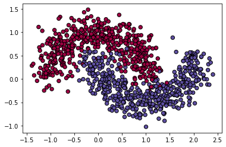

```python
import matplotlib.pyplot as plt

fig, ax = plt.subplots()
ax.scatter(X[:, 0], X[:, 1], c=y.ravel(), s=40, cmap=plt.cm.Spectral, edgecolors='black')
plt.show()
```

```python
# Init architecture
nn_architecture = [
    {"input_dim": 2, "output_dim": 32, "activation": "relu"},
    {"input_dim": 32, "output_dim": 1, "activation": "sigmoid"},
]
# Training
params_values = gradient_descent(X_train.T, (y_train.reshape((y_train.shape[0], 1))).T, nn_architecture, 10000, 0.001)
```

```
Iteration: 00000 - cross entropy: 0.67790 - accuracy: 0.50
Iteration: 00500 - cross entropy: 0.66649 - accuracy: 0.52
Iteration: 01000 - cross entropy: 0.65468 - accuracy: 0.67
Iteration: 01500 - cross entropy: 0.64201 - accuracy: 0.77
Iteration: 02000 - cross entropy: 0.62813 - accuracy: 0.80
Iteration: 02500 - cross entropy: 0.61290 - accuracy: 0.81
Iteration: 03000 - cross entropy: 0.59622 - accuracy: 0.81
Iteration: 03500 - cross entropy: 0.57829 - accuracy: 0.82
Iteration: 04000 - cross entropy: 0.55950 - accuracy: 0.82
Iteration: 04500 - cross entropy: 0.54022 - accuracy: 0.82
Iteration: 05000 - cross entropy: 0.52074 - accuracy: 0.82
Iteration: 05500 - cross entropy: 0.50147 - accuracy: 0.81
Iteration: 06000 - cross entropy: 0.48274 - accuracy: 0.82
Iteration: 06500 - cross entropy: 0.46486 - accuracy: 0.82
Iteration: 07000 - cross entropy: 0.44806 - accuracy: 0.83
Iteration: 07500 - cross entropy: 0.43252 - accuracy: 0.83
Iteration: 08000 - cross entropy: 0.41835 - accuracy: 0.83
Iteration: 08500 - cross entropy: 0.40550 - accuracy: 0.83
Iteration: 09000 - cross entropy: 0.39392 - accuracy: 0.83
Iteration: 09500 - cross entropy: 0.38352 - accuracy: 0.83
```

## TensorFlow 簡介

## TensorFlow 是 Google Brain 團隊開發的機器學習框架

## TensorFlow 提供什麼功能？

- 高階 API：`tf.keras`、`tf.estimator` 等
- 低階 API：`tf.nn`、`tf.rnn`、`tf.train` 等
- 輸入輸出：`tf.data`、`tf.io`、`tf.image` 等
- 計算梯度：`tf.GradientTape`、`tf.gradients`
- 科學計算：`tf.math`、`tf.linalg` 等
- ...其他

## 使用習慣的演進

- 第一個世代的 TensorFlow 採用 Graphs
- 第三個世代的 TensorFlow 採用 NumPy-like 的 Eager Execution

## 使用習慣的演進

- 第一個世代的 TensorFlow 採用 Graphs
- 第三個世代的 TensorFlow 採用 NumPy-like 的 Eager Execution

## MNIST 與 `tf.keras`

## 初始化

```python
import tensorflow as tf

model = tf.keras.Sequential()
```

## 加入一層有 256 個神經元的全連結隱藏層

```python
model.add(tf.keras.layers.Dense(input_dim=28*28, units=2**8, activation="relu"))
```

## 再加入一層有 256 個神經元的全連結隱藏層

```python
model.add(tf.keras.layers.Dense(units=2**8, activation="relu"))
```

## 最後加入有 10 個神經元的輸出層

```python
model.add(tf.keras.layers.Dense(units=10, activation="sigmoid"))
```

## 檢視神經網路架構

```python
model.summary()
```

```
Model: "sequential"
_________________________________________________________________
Layer (type)                 Output Shape              Param #
=================================================================
dense (Dense)                (None, 256)               200960
_________________________________________________________________
dense_1 (Dense)              (None, 256)               65792
_________________________________________________________________
dense_2 (Dense)              (None, 10)                2570
=================================================================
Total params: 269,322
Trainable params: 269,322
Non-trainable params: 0
_________________________________________________________________
```

## 編譯模型

```python
model.compile(loss='categorical_crossentropy',
             optimizer='adam',
             metrics=['accuracy'])
```

## 下載資料與標準化

```python
# 下載資料
(x_train, y_train), (x_test, y_test) = tf.keras.datasets.mnist.load_data()
# 標準化
x_train = x_train.astype('float32') / 255
x_test = x_test.astype('float32') / 255
print("x_train shape:", x_train.shape, "y_train shape:", y_train.shape)
```

```
x_train shape: (60000, 28, 28) y_train shape: (60000,)
```

## 切割資料

```python
# 訓練與驗證
x_train, x_valid = x_train[5000:], x_train[:5000]
y_train, y_valid = y_train[5000:], y_train[:5000]
# 調整外觀
w, h = 28, 28
x_train = x_train.reshape(x_train.shape[0], w*h)
x_valid = x_valid.reshape(x_valid.shape[0], w*h)
x_test = x_test.reshape(x_test.shape[0], w*h)
# One-hot encoding
y_train = tf.keras.utils.to_categorical(y_train, 10)
y_valid = tf.keras.utils.to_categorical(y_valid, 10)
y_test = tf.keras.utils.to_categorical(y_test, 10)
```

## 訓練模型

```python
model.fit(x_train,
         y_train,
         batch_size=64,
         epochs=5,
         validation_data=(x_valid, y_valid))
```

```
<tensorflow.python.keras.callbacks.History at 0x7ff382c9ea90>
```

## 評估模型的表現

```python
score = model.evaluate(x_valid, y_valid)
loss, accuracy = score
print("Loss(cross entropy): {}".format(loss))
print("Accuracy: {:.2f}%".format(accuracy*100))
```

```
Loss(cross entropy): 0.07361342757940292
Accuracy: 97.76%
```

## 對無標籤資料應用

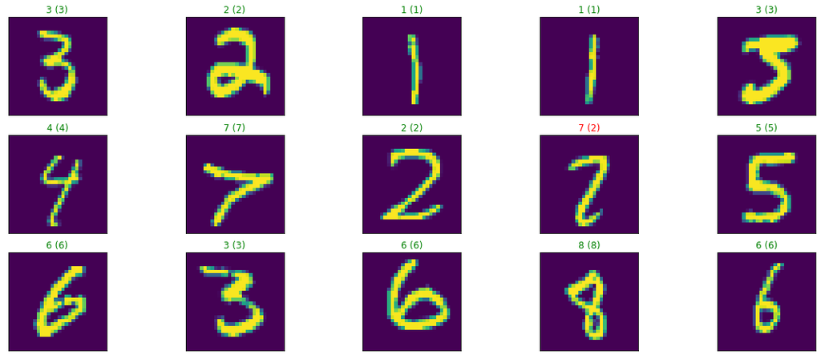

```python
y_hat = model.predict(x_test)
figure = plt.figure(figsize=(20, 8))
np.random.seed(87)
for i, index in enumerate(np.random.choice(x_test.shape[0], size=15, replace=False)):
    ax = figure.add_subplot(3, 5, i + 1, xticks=[], yticks=[])
    ax.imshow(x_test[index].reshape(28, 28))
    predict_index = np.argmax(y_hat[index])
    true_index = np.argmax(y_test[index])
    ax.set_title("{} ({})".format(predict_index, true_index),
                                  color=("green" if predict_index == true_index else "red"))
```

## 改建立 CNN 的神經網路架構

```python
model = tf.keras.Sequential()

model.add(tf.keras.layers.Conv2D(filters=64, kernel_size=2, padding='same', activation='relu', input_shape=(28,28,1)))
model.add(tf.keras.layers.MaxPooling2D(pool_size=2))
model.add(tf.keras.layers.Dropout(0.3))
model.add(tf.keras.layers.Conv2D(filters=32, kernel_size=2, padding='same', activation='relu'))
model.add(tf.keras.layers.MaxPooling2D(pool_size=2))
model.add(tf.keras.layers.Dropout(0.3))
model.add(tf.keras.layers.Flatten())
model.add(tf.keras.layers.Dense(256, activation='relu'))
model.add(tf.keras.layers.Dropout(0.5))
model.add(tf.keras.layers.Dense(10, activation='softmax'))

model.summary()
```

```
Model: "sequential_1"
_________________________________________________________________
Layer (type)                 Output Shape              Param #
=================================================================
conv2d (Conv2D)              (None, 28, 28, 64)        320
_________________________________________________________________
max_pooling2d (MaxPooling2D) (None, 14, 14, 64)        0
_________________________________________________________________
dropout (Dropout)            (None, 14, 14, 64)        0
_________________________________________________________________
conv2d_1 (Conv2D)            (None, 14, 14, 32)        8224
_________________________________________________________________
max_pooling2d_1 (MaxPooling2 (None, 7, 7, 32)          0
_________________________________________________________________
dropout_1 (Dropout)          (None, 7, 7, 32)          0
_________________________________________________________________
flatten (Flatten)            (None, 1568)              0
_________________________________________________________________
dense_3 (Dense)              (None, 256)               401664
_________________________________________________________________
dropout_2 (Dropout)          (None, 256)               0
_________________________________________________________________
dense_4 (Dense)              (None, 10)                2570
=================================================================
Total params: 412,778
Trainable params: 412,778
Non-trainable params: 0
_________________________________________________________________
```

## 編譯模型

```python
model.compile(loss='categorical_crossentropy',
             optimizer='adam',
             metrics=['accuracy'])
```

## 調整資料的外觀

```python
# 下載資料
(x_train, y_train), (x_test, y_test) = tf.keras.datasets.mnist.load_data()
# 標準化
x_train = x_train.astype('float32') / 255
x_test = x_test.astype('float32') / 255
# 訓練與驗證
x_train, x_valid = x_train[5000:], x_train[:5000]
y_train, y_valid = y_train[5000:], y_train[:5000]
# 調整外觀
w, h = 28, 28
x_train = x_train.reshape(x_train.shape[0], w, h, 1)
x_valid = x_valid.reshape(x_valid.shape[0], w, h, 1)
x_test = x_test.reshape(x_test.shape[0], w, h, 1)
# One-hot encoding
y_train = tf.keras.utils.to_categorical(y_train, 10)
y_valid = tf.keras.utils.to_categorical(y_valid, 10)
y_test = tf.keras.utils.to_categorical(y_test, 10)
```

## 訓練模型

```python
model.fit(x_train,
         y_train,
         batch_size=64,
         epochs=5,
         validation_data=(x_valid, y_valid))
```

```
<tensorflow.python.keras.callbacks.History at 0x7ff372c26b70>
```

## 評估模型的表現

```python
score = model.evaluate(x_valid, y_valid)
loss, accuracy = score
print("Loss(cross entropy): {}".format(loss))
print("Accuracy: {:.2f}%".format(accuracy*100))
```

```
Loss(cross entropy): 0.04287707060575485
Accuracy: 98.70%
```

## 時裝 MNIST 與 `tf.keras`

## 沿用 CNN 的神經網路架構

```python
model.summary()
```

```
Model: "sequential_1"
_________________________________________________________________
Layer (type)                 Output Shape              Param #
=================================================================
conv2d (Conv2D)              (None, 28, 28, 64)        320
_________________________________________________________________
max_pooling2d (MaxPooling2D) (None, 14, 14, 64)        0
_________________________________________________________________
dropout (Dropout)            (None, 14, 14, 64)        0
_________________________________________________________________
conv2d_1 (Conv2D)            (None, 14, 14, 32)        8224
_________________________________________________________________
max_pooling2d_1 (MaxPooling2 (None, 7, 7, 32)          0
_________________________________________________________________
dropout_1 (Dropout)          (None, 7, 7, 32)          0
_________________________________________________________________
flatten (Flatten)            (None, 1568)              0
_________________________________________________________________
dense_3 (Dense)              (None, 256)               401664
_________________________________________________________________
dropout_2 (Dropout)          (None, 256)               0
_________________________________________________________________
dense_4 (Dense)              (None, 10)                2570
=================================================================
Total params: 412,778
Trainable params: 412,778
Non-trainable params: 0
_________________________________________________________________
```

## 下載資料與標準化

```python
# 下載資料
(x_train, y_train), (x_test, y_test) = tf.keras.datasets.fashion_mnist.load_data()
# 標準化
x_train = x_train.astype('float32') / 255
x_test = x_test.astype('float32') / 255
print("x_train shape:", x_train.shape, "y_train shape:", y_train.shape)
```

```
x_train shape: (60000, 28, 28) y_train shape: (60000,)
```

## 切割資料

```python
# 訓練與驗證
x_train, x_valid = x_train[5000:], x_train[:5000]
y_train, y_valid = y_train[5000:], y_train[:5000]
# 調整外觀
w, h = 28, 28
x_train = x_train.reshape(x_train.shape[0], w, h, 1)
x_valid = x_valid.reshape(x_valid.shape[0], w, h, 1)
x_test = x_test.reshape(x_test.shape[0], w, h, 1)
# One-hot encoding
y_train = tf.keras.utils.to_categorical(y_train, 10)
y_valid = tf.keras.utils.to_categorical(y_valid, 10)
y_test = tf.keras.utils.to_categorical(y_test, 10)
```

## 訓練模型

```python
model.fit(x_train,
         y_train,
         batch_size=64,
         epochs=5,
         validation_data=(x_valid, y_valid)
         )
```

```
<tensorflow.python.keras.callbacks.History at 0x7ff3731ceac8>
```

## 對應分類

```python
fashion_mnist_labels = ["T-shirt/top",  # index 0
                        "Trouser",      # index 1
                        "Pullover",     # index 2
                        "Dress",        # index 3
                        "Coat",         # index 4
                        "Sandal",       # index 5
                        "Shirt",        # index 6
                        "Sneaker",      # index 7
                        "Bag",          # index 8
                        "Ankle boot"]   # index 9
```

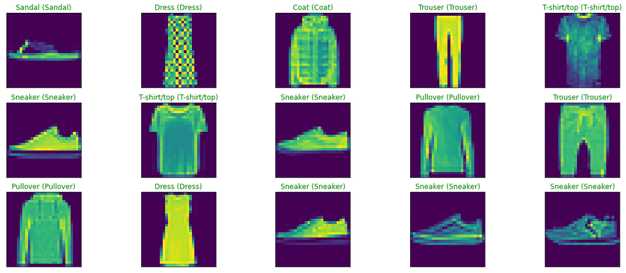

```python
y_hat = model.predict(x_test)
figure = plt.figure(figsize=(20, 8))
np.random.seed(87)
for i, index in enumerate(np.random.choice(x_test.shape[0], size=15, replace=False)):
    ax = figure.add_subplot(3, 5, i + 1, xticks=[], yticks=[])
    ax.imshow(np.squeeze(x_test[index]))
    predict_index = np.argmax(y_hat[index])
    true_index = np.argmax(y_test[index])
    ax.set_title("{} ({})".format(fashion_mnist_labels[predict_index],
                                  fashion_mnist_labels[true_index]),
                                  color=("green" if predict_index == true_index else "red"))
```